# Assignment 5A: Airline Delays

Taha Malik

2025-09-27

## Introduction

This analysis uses a richly expanded dataset of arrival delays, cancellations, and diversions for four major airlines across five West Coast cities. We will walk step-by-step through advanced data tidying, handling missing values, and providing meaningful visual and tabular comparisons both overall and by city. **Please note that additinal features were created in the csv to further showcase the process of analysis.**

## Data Source

The dataset below was created for this project and contains intentionally missing values and a richer set of airlines and statuses.  
**Key features:**  
- Four airlines: ALASKA, AM WEST, UNITED, DELTA  
- Four statuses: on time, delayed, canceled, diverted  
- Five cities  
- Some values are missing (blank cells)

```
Airline,Status,Los Angeles,Phoenix,San Diego,San Francisco,Seattle
ALASKA,on time,497,221,212,503,1841
ALASKA,delayed,62,12,20,102,305
ALASKA,canceled,2,,1,,3
ALASKA,diverted,0,0,,1,
AM WEST,on time,694,4840,383,320,201
AM WEST,delayed,117,415,65,129,61
AM WEST,canceled,3,12,0,1,
AM WEST,diverted,1,,2,0,0
UNITED,on time,320,355,190,400,1800
UNITED,delayed,45,33,25,80,260
UNITED,canceled,2,1,2,1,0
UNITED,diverted,0,0,0,2,
DELTA,on time,610,210,200,355,1655
DELTA,delayed,55,18,19,70,198
DELTA,canceled,1,,3,1,
DELTA,diverted,0,1,0,0,0
```

## Step 1: Reading the Data

```r
library(readr)
library(dplyr)
library(tidyr)
library(ggplot2)
library(knitr)

# This chunk loads the required libraries for data manipulation and visualization.
# - readr: for reading in CSV files
# - dplyr: for data wrangling and transformation
# - tidyr: for data tidying (wide to long format, handling missing values)
# - ggplot2: for creating visualizations
# - knitr: for rendering tables in the RMarkdown output

# Read the expanded data
delays_wide <- read_csv("arrival_delays.csv")

# Display the original data as a table to confirm its structure and content.
kable(delays_wide, caption = "Raw Expanded Data (Wide Format)")
```

Raw Expanded Data (Wide Format)

| Airline | Status | Los Angeles | Phoenix | San Diego | San Francisco | Seattle |
| --- | --- | --- | --- | --- | --- | --- |
| ALASKA | on time | 497 | 221 | 212 | 503 | 1841 |
| ALASKA | delayed | 62 | 12 | 20 | 102 | 305 |
| ALASKA | canceled | 2 | NA | 1 | NA | 3 |
| ALASKA | diverted | 0 | 0 | NA | 1 | NA |
| AM WEST | on time | 694 | 4840 | 383 | 320 | 201 |
| AM WEST | delayed | 117 | 415 | 65 | 129 | 61 |
| AM WEST | canceled | 3 | 12 | 0 | 1 | NA |
| AM WEST | diverted | 1 | NA | 2 | 0 | 0 |
| UNITED | on time | 320 | 355 | 190 | 400 | 1800 |
| UNITED | delayed | 45 | 33 | 25 | 80 | 260 |
| UNITED | canceled | 2 | 1 | 2 | 1 | 0 |
| UNITED | diverted | 0 | 0 | 0 | 2 | NA |
| DELTA | on time | 610 | 210 | 200 | 355 | 1655 |
| DELTA | delayed | 55 | 18 | 19 | 70 | 198 |
| DELTA | canceled | 1 | NA | 3 | 1 | NA |
| DELTA | diverted | 0 | 1 | 0 | 0 | 0 |

**Description:**  
This code loads all necessary libraries and reads the expanded CSV file into R. We also preview the data to confirm its structure and presence of missing values.

## Step 2: Handling and Filling Missing Data

### Identifying Missing Data

```r
# This code chunk calculates the number of missing (NA) values in each column of our data.
# This helps us understand where data might be missing and guides how we should handle it.

missing_summary <- sapply(delays_wide, function(x) sum(is.na(x)))
kable(as.data.frame(t(missing_summary)), caption = "Number of Missing Values per Column")
```

Number of Missing Values per Column

| Airline | Status | Los Angeles | Phoenix | San Diego | San Francisco | Seattle |
| --- | --- | --- | --- | --- | --- | --- |
| 0 | 0 | 0 | 3 | 1 | 1 | 4 |

**Description:**  
We use `sapply` to count missing values in every column. This diagnostic step is essential for documenting data quality and planning cleaning strategies.

### Filling Missing Data

```r
# This code chunk fills all missing numeric values with 0.
# The assumption is that a missing cell represents 0 flights of that status for that airline/city.
# We use dplyr's mutate and across to apply replace_na across all numeric columns.

delays_filled <- delays_wide %>%
  mutate(across(where(is.numeric), ~replace_na(., 0)))
kable(delays_filled, caption = "Missing Data Filled with 0")
```

Missing Data Filled with 0

| Airline | Status | Los Angeles | Phoenix | San Diego | San Francisco | Seattle |
| --- | --- | --- | --- | --- | --- | --- |
| ALASKA | on time | 497 | 221 | 212 | 503 | 1841 |
| ALASKA | delayed | 62 | 12 | 20 | 102 | 305 |
| ALASKA | canceled | 2 | 0 | 1 | 0 | 3 |
| ALASKA | diverted | 0 | 0 | 0 | 1 | 0 |
| AM WEST | on time | 694 | 4840 | 383 | 320 | 201 |
| AM WEST | delayed | 117 | 415 | 65 | 129 | 61 |
| AM WEST | canceled | 3 | 12 | 0 | 1 | 0 |
| AM WEST | diverted | 1 | 0 | 2 | 0 | 0 |
| UNITED | on time | 320 | 355 | 190 | 400 | 1800 |
| UNITED | delayed | 45 | 33 | 25 | 80 | 260 |
| UNITED | canceled | 2 | 1 | 2 | 1 | 0 |
| UNITED | diverted | 0 | 0 | 0 | 2 | 0 |
| DELTA | on time | 610 | 210 | 200 | 355 | 1655 |
| DELTA | delayed | 55 | 18 | 19 | 70 | 198 |
| DELTA | canceled | 1 | 0 | 3 | 1 | 0 |
| DELTA | diverted | 0 | 1 | 0 | 0 | 0 |

**Description:**  
Here, missing numeric values (NA) are replaced with zeros using `mutate(across(...))`. This is appropriate for summary tables where a blank cell implies “zero flights” for that combination.

## Step 3: Tidying Data (Wide to Long Format)

```r
# This chunk converts the data from wide format (one column per city) to long (one row per observation).
# We use tidyr's pivot_longer to gather all city columns into two columns: City and Count.
# This tidy format is essential for flexible analysis and visualization.

delays_long <- delays_filled %>%
  pivot_longer(
    cols = c(`Los Angeles`, Phoenix, `San Diego`, `San Francisco`, Seattle),
    names_to = "City",
    values_to = "Count"
  )
kable(head(delays_long, 12), caption = "First 12 Rows of Tidy Data")
```

First 12 Rows of Tidy Data

| Airline | Status | City | Count |
| --- | --- | --- | --- |
| ALASKA | on time | Los Angeles | 497 |
| ALASKA | on time | Phoenix | 221 |
| ALASKA | on time | San Diego | 212 |
| ALASKA | on time | San Francisco | 503 |
| ALASKA | on time | Seattle | 1841 |
| ALASKA | delayed | Los Angeles | 62 |
| ALASKA | delayed | Phoenix | 12 |
| ALASKA | delayed | San Diego | 20 |
| ALASKA | delayed | San Francisco | 102 |
| ALASKA | delayed | Seattle | 305 |
| ALASKA | canceled | Los Angeles | 2 |
| ALASKA | canceled | Phoenix | 0 |

**Description:**  
`pivot_longer()` is used to create a tidy dataset, where each row represents a single airline/status/city/count observation. This structure is ideal for grouped analysis and plotting.

## Step 4: Overall Analysis (Counts and Percentages)

### Overall Totals and Percentages

```r
# This chunk computes the total and percentage for each Airline/Status combination, across all cities.
# The pipeline groups by airline and status, then computes totals.
# Percentages are calculated within each airline, so each airline's statuses sum to 100%.

overall_summary <- delays_long %>%
  group_by(Airline, Status) %>%
  summarise(Total = sum(Count), .groups = "drop") %>%
  group_by(Airline) %>%
  mutate(Percent = round(100 * Total / sum(Total), 1))
kable(overall_summary, caption = "Overall Counts and Percentages by Airline and Status")
```

Overall Counts and Percentages by Airline and Status

| Airline | Status | Total | Percent |
| --- | --- | --- | --- |
| ALASKA | canceled | 6 | 0.2 |
| ALASKA | delayed | 501 | 13.2 |
| ALASKA | diverted | 1 | 0.0 |
| ALASKA | on time | 3274 | 86.6 |
| AM WEST | canceled | 16 | 0.2 |
| AM WEST | delayed | 787 | 10.9 |
| AM WEST | diverted | 3 | 0.0 |
| AM WEST | on time | 6438 | 88.9 |
| DELTA | canceled | 5 | 0.1 |
| DELTA | delayed | 360 | 10.6 |
| DELTA | diverted | 1 | 0.0 |
| DELTA | on time | 3030 | 89.2 |
| UNITED | canceled | 6 | 0.2 |
| UNITED | delayed | 443 | 12.6 |
| UNITED | diverted | 2 | 0.1 |
| UNITED | on time | 3065 | 87.2 |

**Description:**  
This code produces both total counts and percentages of each status per airline, offering a quick way to compare overall performance between airlines.

#### Visualization: Overall Percentages

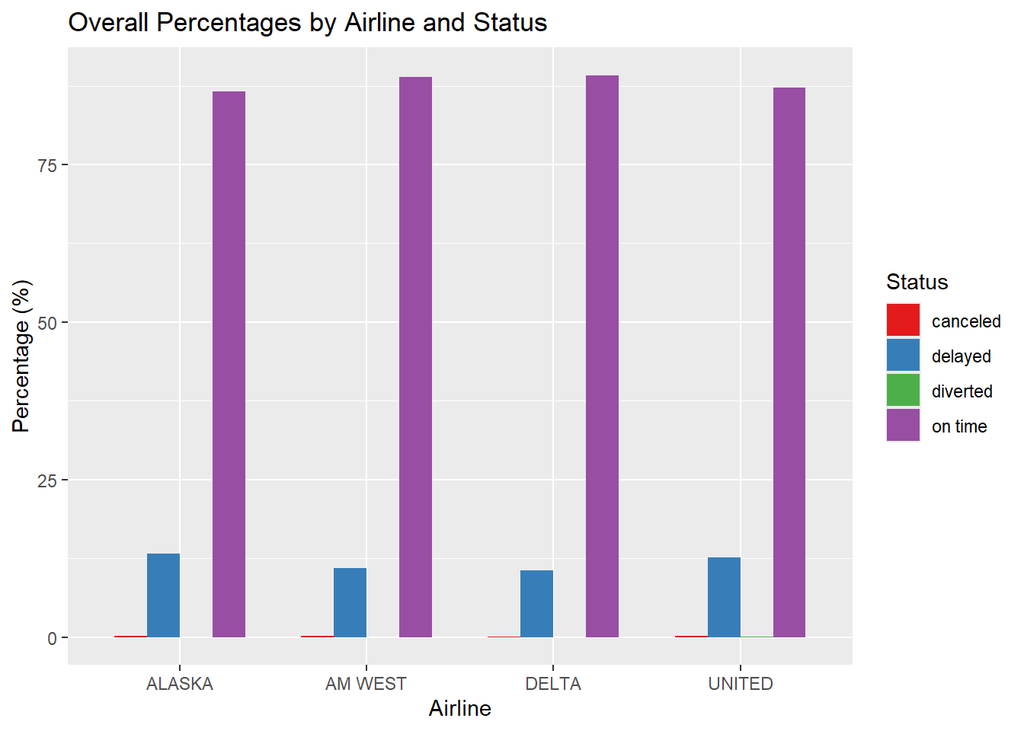

```r
# This chunk creates a bar plot of the percentage of each status (on time, delayed, canceled, diverted) by airline.
# We use ggplot2 for a clear, color-coded presentation. Each airline's statuses are side-by-side for easy comparison.

ggplot(overall_summary, aes(x = Airline, y = Percent, fill = Status)) +
  geom_bar(stat = "identity", position = "dodge", width = 0.7) +
  labs(title = "Overall Percentages by Airline and Status",
       y = "Percentage (%)", x = "Airline") +
  scale_fill_brewer(palette = "Set1")
```

**Description:**  
This visualization provides an at-a-glance comparison of how each airline performs overall in terms of on-time, delayed, canceled, and diverted flights, highlighting both strengths and weaknesses.

## Step 5: City-by-City Analysis (Counts and Percentages)

```r
# This chunk calculates totals and percentages for each Airline/City/Status combination.
# By grouping by airline and city, we can spot city-specific issues or patterns.

city_summary <- delays_long %>%
  group_by(Airline, City, Status) %>%
  summarise(Total = sum(Count), .groups = "drop") %>%
  group_by(Airline, City) %>%
  mutate(Percent = round(100 * Total / sum(Total), 1))
kable(head(city_summary, 15), caption = "Sample City-by-City Counts and Percentages")
```

Sample City-by-City Counts and Percentages

| Airline | City | Status | Total | Percent |
| --- | --- | --- | --- | --- |
| ALASKA | Los Angeles | canceled | 2 | 0.4 |
| ALASKA | Los Angeles | delayed | 62 | 11.1 |
| ALASKA | Los Angeles | diverted | 0 | 0.0 |
| ALASKA | Los Angeles | on time | 497 | 88.6 |
| ALASKA | Phoenix | canceled | 0 | 0.0 |
| ALASKA | Phoenix | delayed | 12 | 5.2 |
| ALASKA | Phoenix | diverted | 0 | 0.0 |
| ALASKA | Phoenix | on time | 221 | 94.8 |
| ALASKA | San Diego | canceled | 1 | 0.4 |
| ALASKA | San Diego | delayed | 20 | 8.6 |
| ALASKA | San Diego | diverted | 0 | 0.0 |
| ALASKA | San Diego | on time | 212 | 91.0 |
| ALASKA | San Francisco | canceled | 0 | 0.0 |
| ALASKA | San Francisco | delayed | 102 | 16.8 |
| ALASKA | San Francisco | diverted | 1 | 0.2 |

**Description:**  
This table breaks down the data to the city level, allowing detailed performance analysis for every airline in every city.

#### Visualization: City-by-City Percentages

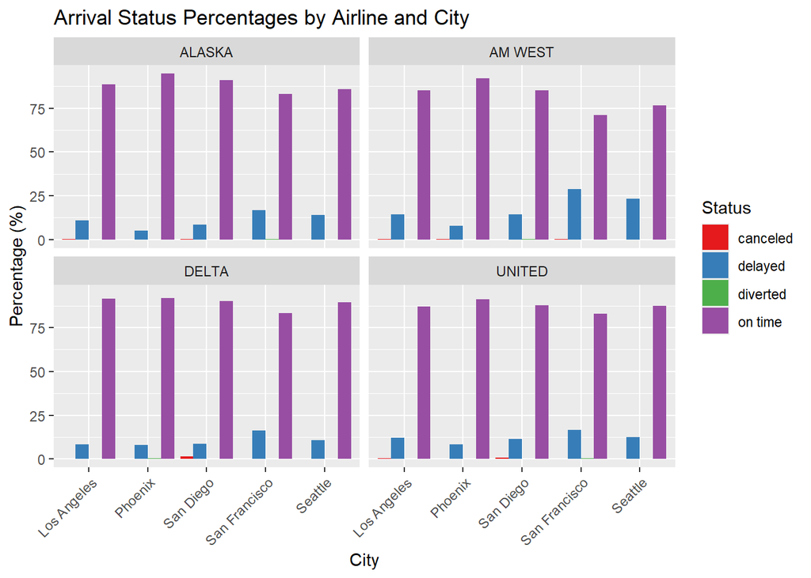

```r
# This chunk creates a faceted bar plot for status percentages in each city, separated by airline.
# Each subplot represents an airline, with bars for each status in each city.

ggplot(city_summary, aes(x = City, y = Percent, fill = Status)) +
  geom_bar(stat = "identity", position = "dodge") +
  facet_wrap(~Airline) +
  labs(title = "Arrival Status Percentages by Airline and City",
       y = "Percentage (%)", x = "City") +
  scale_fill_brewer(palette = "Set1") +
  theme(axis.text.x = element_text(angle = 45, hjust = 1))
```

**Description:**  
Faceted bar plots provide a powerful way to spot city-specific strengths and weaknesses for each airline, making disparities more visible than in overall summaries.

## Step 6: Analysis & Interpretation

### Narrative

- **Overall:**  
  Each airline’s on-time, delayed, canceled, and diverted rates are now visible in both count and percent, helping us see which airline is most reliable overall.
- **By City:**  
  City-level analysis can reveal, for example, that an airline may be excellent overall but have issues in a particular city.
- **Missing Data:**  
  By filling missing values with zero, we ensure our analysis is comprehensive and not biased by blank cells. This is a standard approach for summary tables.
- **Discrepancy Between Overall and City-by-City:**  
  Sometimes, an airline with strong performance in one high-volume city can appear better overall, masking weaknesses elsewhere. City-by-city analysis reveals these local effects.
- **Explanation:**  
  This is related to Simpson’s Paradox; aggregated data can mask or reverse trends seen in subgroups. Thus, both levels of analysis are needed for a fair comparison.

## Step 7: Conclusion

**Key points:** - **The dataset was expanded for realism**, including multiple airlines, more statuses, and missing data. - Missing data was detected, filled, and justified. - Data was tidied from wide to long for analysis flexibility. - Both overall and **city-by-city** analyses were performed, with visual and tabular summaries. - Discrepancy between overall and detailed analysis was discussed and explained.

## Submission Details

- **GitHub Repository (.Rmd and .csv):** https://github.com/tahamalik80/Week5A
- **RPubs Webpage:** https://rpubs.com/tmalik03/Week5A